# R Notebook

#trial PVA

####Exponential growth#####

A simple population modelling Remember: Population size = N delta N = change in population size delta N = N(t+1)-Nt Delta N = B+I-D-E B = birth I = immigration D = death E = emigration

or N = B-D Number of birth and death in a population is not constant (important point) what is more constant in per-capita rate of producing offspring, or dying

example: for every individual in the population now, we expect 0.8 new juveniles to enter the population in the coming year for every female in the population, we expect 1.1 offspring will be born this year we expect 3% of the current population to die in the coming year

these per-capita usually expressed as lower case letter, thus b = per-capita birth rate d = [er-capita death rate

to compute these (also known as population vital rates), you can b = Bt/Nt (divide the total number of Birth B or Death D by the population size N at given times) d = Dt/Nt

delta N = b.Nt - d.Nt delta N = (b-d) x Nt If b-d = r (differences between per-capita birth and death) delta N = r x Nt

these are the most fundamental things in the population ecology

(follow notes based on lab exercise here)

```r
getwd()
```

```
[1] "/Users/adachornelia/Documents/PVA-neofelis diardi"
```

# set the parameter

```r
r = 0.1 #percapita growth rate
lambda = 1 + r #1+r is equal to lambda, the finite rate of growth
N0 = 100 #initial population size
nyears= 30 #number of time step (in years) to stimulate

#how we predict the number of population size in next 30 years?
year = seq(from = 0, to = nyears, by = 1) #create sequence number from 0 to nyears (30), and increment this sequence by 1 = vector
year
```

```
 [1]  0  1  2  3  4  5  6  7  8  9 10 11 12 13 14 15 16 17 18 19 20 21 22 23 24 25 26 27 28 29 30
```

```r
# build a storage structure to store simulated population size over this time period
N = numeric (nyears+1) #numeric to take the contents within the parentheses and conevert it to numeric classes
names(N) = year
N
```

```
 0  1  2  3  4  5  6  7  8  9 10 11 12 13 14 15 16 17 18 19 20 21 22 23 24 25 26 27 28 29 30
 0  0  0  0  0  0  0  0  0  0  0  0  0  0  0  0  0  0  0  0  0  0  0  0  0  0  0  0  0  0  0
```

#run the simulation

```r
N[1] = N0 #vector number 1 will change to N0 (initial pop size)
for (i in 2:(nyears+1)){  # This for-loop will run through the line of code between the curly brackets {}. "i" is simply the name of a variable (you can use "j", or "k", instead -- any variable name will do). "i" changes each time the loop iterates; basically, it will increase by 1 each time the loop is run, starting at "2" up until the specified maximum number of loops "nyears+1".
  N[i] <- N[i-1] * lambda  # This takes the [i - 1] element of "N", multiplies that element by the value of lambda, then assigns that calculated result to the [i] element of "N".
}                         # This ends the for-loop.

N
```

```
        0         1         2         3         4         5         6         7         8
 100.0000  110.0000  121.0000  133.1000  146.4100  161.0510  177.1561  194.8717  214.3589
        9        10        11        12        13        14        15        16        17
 235.7948  259.3742  285.3117  313.8428  345.2271  379.7498  417.7248  459.4973  505.4470
       18        19        20        21        22        23        24        25        26
 555.9917  611.5909  672.7500  740.0250  814.0275  895.4302  984.9733 1083.4706 1191.8177
       27        28        29        30
1310.9994 1442.0994 1586.3093 1744.9402
```

#plot

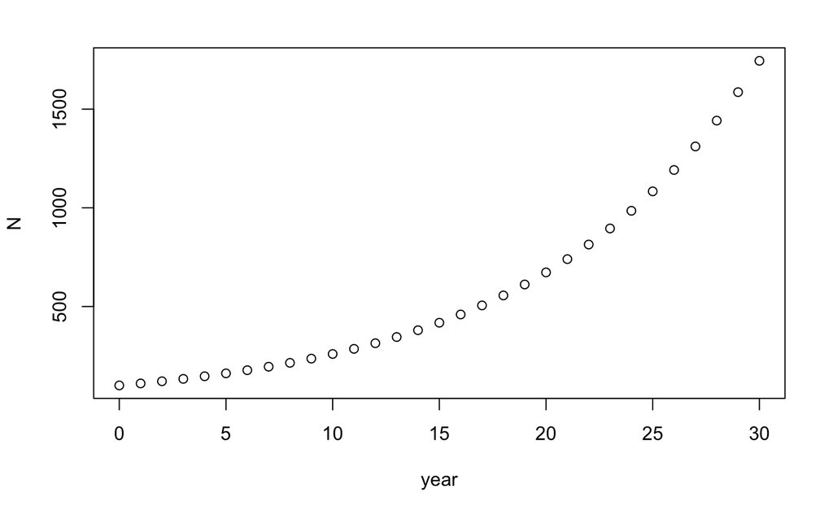

```r
plot(N~year)
```

###########end here#########

#add density dependences and carrying capacity

b = bmax - aN, density dependence birth rate = most favorable (max) birth rate - (strenght of density dependence*N) d = dmin + cN , density-dependence death rate = most favorable (min) death rate + strength of density dependence* N)

```r
Density = seq (0, 15000, 10) #create a sequence of numbers from 0 to 15000, representing range of population densities

## constant
b_max = 0.85 #maximum reproduction at low densities
d_min = 0.3 #minimum mortaliti at low densities

a = 0.00007 #d-d terms
c = 0.00003

b = b_max - a*Density
d = d_min + c*Density

K <- (b_max-d_min)/(a+c)   # compute carrying capacity
K
```

```
[1] 5500
```

```r
plot(Density,b,type="l",col="green",lwd=2,ylim=c(0,2),main="Density-Dependence!",xlim=c(0,15000),ylab="Vital rate (b or d)")
points(Density,d,type="l",col="red",lwd=2)
```

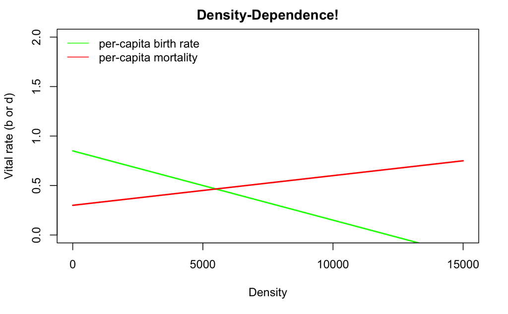

```r
legend("topleft",col=c("green","red"),lty=c(1,1),legend=c("per-capita birth rate","per-capita mortality"),bty="n")
```

```r
NA
NA
```

##end here